# code.Rmd

Marcelladane

13 September 2017

## Project Summary

Based on the data from http://groupware.les.inf.puc-rio.br/har we will try to create a model to predict what exercise was performed. To do so, we have a database of 159 features.

*Steps to achieve our goal:*

- Process and explore the data
- Model selection (try to find a model to answer our question)
- Model examination (using the test set to check how good is the model)
- Conclusions

## Processing and Exploring

Load the data

```r
Training <- read.csv("pml-training.csv")
Test <- read.csv("pml-testing.csv")
```

Explore the features of the data

```r
dim(Training)
```

```
## [1] 19622   160
```

```r
head(Training)
```

```
##   X user_name raw_timestamp_part_1 raw_timestamp_part_2   cvtd_timestamp new_window num_window roll_belt pitch_belt
## 1 1  carlitos           1323084231               788290 05/12/2011 11:23         no         11      1.41       8.07
## 2 2  carlitos           1323084231               808298 05/12/2011 11:23         no         11      1.41       8.07
## 3 3  carlitos           1323084231               820366 05/12/2011 11:23         no         11      1.42       8.07
## 4 4  carlitos           1323084232               120339 05/12/2011 11:23         no         12      1.48       8.05
## 5 5  carlitos           1323084232               196328 05/12/2011 11:23         no         12      1.48       8.07
## 6 6  carlitos           1323084232               304277 05/12/2011 11:23         no         12      1.45       8.06
##   yaw_belt total_accel_belt kurtosis_roll_belt kurtosis_picth_belt kurtosis_yaw_belt skewness_roll_belt
## 1    -94.4                3
## 2    -94.4                3
## 3    -94.4                3
## 4    -94.4                3
## 5    -94.4                3
## 6    -94.4                3
##   skewness_roll_belt.1 skewness_yaw_belt max_roll_belt max_picth_belt max_yaw_belt min_roll_belt min_pitch_belt
```

[output cut: 160 more lines]

```r
str(Training)
```

```
## 'data.frame':    19622 obs. of  160 variables:
##  $ X                       : int  1 2 3 4 5 6 7 8 9 10 ...
##  $ user_name               : Factor w/ 6 levels "adelmo","carlitos",..: 2 2 2 2 2 2 2 2 2 2 ...
##  $ raw_timestamp_part_1    : int  1323084231 1323084231 1323084231 1323084232 1323084232 1323084232 1323084232 1323084232 1323084232 1323084232 ...
##  $ raw_timestamp_part_2    : int  788290 808298 820366 120339 196328 304277 368296 440390 484323 484434 ...
##  $ cvtd_timestamp          : Factor w/ 20 levels "02/12/2011 13:32",..: 9 9 9 9 9 9 9 9 9 9 ...
##  $ new_window              : Factor w/ 2 levels "no","yes": 1 1 1 1 1 1 1 1 1 1 ...
##  $ num_window              : int  11 11 11 12 12 12 12 12 12 12 ...
##  $ roll_belt               : num  1.41 1.41 1.42 1.48 1.48 1.45 1.42 1.42 1.43 1.45 ...
##  $ pitch_belt              : num  8.07 8.07 8.07 8.05 8.07 8.06 8.09 8.13 8.16 8.17 ...
##  $ yaw_belt                : num  -94.4 -94.4 -94.4 -94.4 -94.4 -94.4 -94.4 -94.4 -94.4 -94.4 ...
##  $ total_accel_belt        : int  3 3 3 3 3 3 3 3 3 3 ...
##  $ kurtosis_roll_belt      : Factor w/ 397 levels "","-0.016850",..: 1 1 1 1 1 1 1 1 1 1 ...
##  $ kurtosis_picth_belt     : Factor w/ 317 levels "","-0.021887",..: 1 1 1 1 1 1 1 1 1 1 ...
##  $ kurtosis_yaw_belt       : Factor w/ 2 levels "","#DIV/0!": 1 1 1 1 1 1 1 1 1 1 ...
```

[output cut: 86 more lines]

As we can notice, we have too many NAs, one option is to remove most of them from table. I randomly decided for keep just 1/4 of them.

```r
maxNAPerc = 25
maxNACount <- nrow(Training) / 100 * maxNAPerc
removeColumns <- which(colSums(is.na(Training) | Training=="") > maxNACount)
Training_noNA <- Training[,-removeColumns]
Test_noNA <- Test[,-removeColumns]
```

Then convert all factors to integers

```r
classeLevels <- levels(Training_noNA$classe)
Training_noNA1 <- data.frame(data.matrix(Training_noNA))
Training_noNA1$classe <- factor(Training_noNA1$classe, labels=classeLevels)
Test_noNA1 <- data.frame(data.matrix(Test_noNA))

training.final <- Training_noNA1
testing.final <- Test_noNA1
```

Here I will gonna need to do a partition on the training set, it will not be used, but my computer can’t handle all the data, so I will subset it to facilitate the analysis (I actually tried to run it a couple of times and it requires way more RAM memory than I have).

```r
set.seed(1982)
library(caret)

classeIndex <- which(names(Training_noNA1) == "classe")

partition <- createDataPartition(y=Training_noNA1$classe, p=0.75, list=FALSE)
training.subseted <- Training_noNA1[partition, ]
training.excluded <- Training_noNA1[-partition, ]
```

To check possible correlations, lets first check possible existence of correlations and then plot linear predictors

```r
correlations <- cor(training.subseted[, -classeIndex], as.numeric(training.subseted$classe))
bestCorrelations <- subset(as.data.frame(as.table(correlations)), abs(Freq)>0.2)
bestCorrelations
```

```
##             Var1 Var2       Freq
## 1              X    A  0.9740405
## 19 magnet_belt_y    A -0.2905170
## 28   accel_arm_x    A  0.2384268
## 31  magnet_arm_x    A  0.2902440
## 32  magnet_arm_y    A -0.2524361
## 48 pitch_forearm    A  0.3367126
```

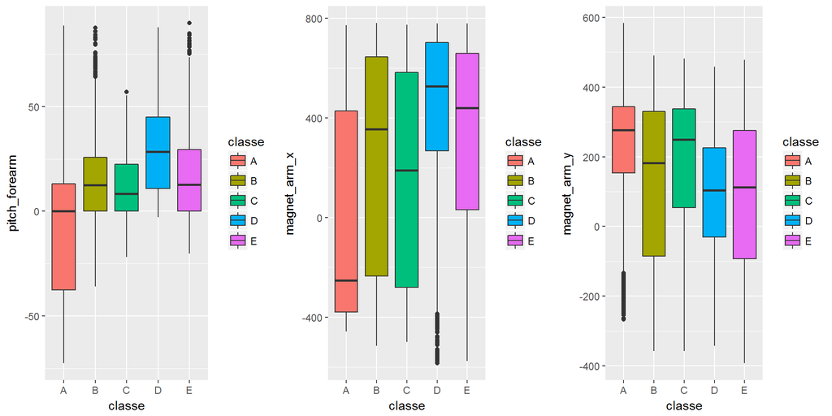

```r
library(Rmisc)
library(ggplot2)

A <- ggplot(training.subseted, aes(classe,pitch_forearm)) + geom_boxplot(aes(fill=classe))

B <- ggplot(training.subseted, aes(classe,magnet_arm_x)) + geom_boxplot(aes(fill=classe))

C <- ggplot(training.subseted, aes(classe,magnet_arm_y)) + geom_boxplot(aes(fill=classe))

multiplot(A, B, C, cols=3)
```

## Model selection

The first step can be to check which variables are highly correlated between themselves, then check how the model behaves if we exclude them.

Now let’s exclude the highly correlated variables

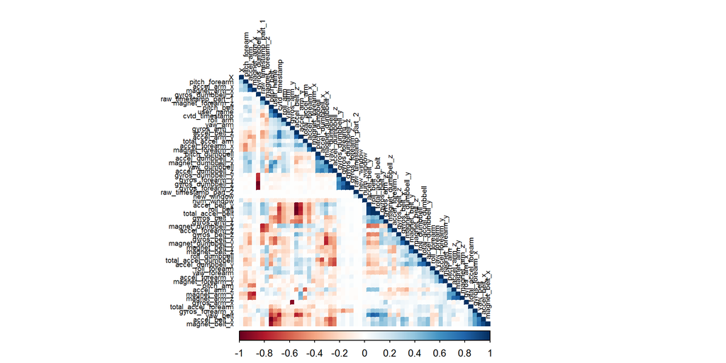

```r
library(corrplot)
correlationMatrix <- cor(training.subseted[, -classeIndex])
highlyCorrelated <- findCorrelation(correlationMatrix, cutoff=0.8, exact=TRUE)
To_exclude <- c(highlyCorrelated, classeIndex)
corrplot(correlationMatrix, method="color", type="lower", order="hclust", tl.cex=0.6, tl.col="black")
```

And now use Random Forest training. For this project I will use 30 trees.And 2 models, one with all data and one without the high correlated variables.

```r
library(randomForest)

ntree <- 30

Model.cleaned <- randomForest(
  x=training.subseted[, -classeIndex],
  y=training.subseted$classe,
  xtest=testing.final[, -classeIndex],
  ytest=testing.final$classe,
  ntree=ntree,
  keep.forest=TRUE,
  proximity=TRUE) #do.trace=TRUE

Model.exclude <- randomForest(
  x=training.subseted[, -To_exclude],
  y=training.subseted$classe,
  xtest=testing.final[, -To_exclude],
  ytest=testing.final$classe,
  ntree=ntree,
  keep.forest=TRUE,
  proximity=TRUE)
```

## Model examination

Now lets see the accuracy of the models and choose the best one

```r
Model.cleaned
```

```
##
## Call:
##  randomForest(x = training.subseted[, -classeIndex], y = training.subseted$classe,      xtest = testing.final[, -classeIndex], ytest = testing.final$classe,      ntree = ntree, proximity = TRUE, keep.forest = TRUE)
##                Type of random forest: classification
##                      Number of trees: 30
## No. of variables tried at each split: 7
##
##         OOB estimate of  error rate: 0.06%
## Confusion matrix:
##      A    B    C    D    E  class.error
## A 4185    0    0    0    0 0.0000000000
## B    0 2846    2    0    0 0.0007022472
## C    0    0 2567    0    0 0.0000000000
## D    0    0    3 2407    2 0.0020729685
## E    0    0    0    2 2704 0.0007390983
```

```r
Accuracy.Mcleaned.training <- round(1-sum(Model.cleaned$confusion[, 'class.error']),3)
paste0("Training (M.cleaned): ",Accuracy.Mcleaned.training)
```

```
## [1] "Training (M.cleaned): 0.996"
```

```r
Accuracy.Mcleaned.test  <- round(1-sum(Model.cleaned$test$confusion[, 'class.error']),3)
paste0("Test (M.cleaned):",Accuracy.Mcleaned.test)
```

```
## [1] "Test (M.cleaned):1"
```

```r
Model.exclude
```

```
##
## Call:
##  randomForest(x = training.subseted[, -To_exclude], y = training.subseted$classe,      xtest = testing.final[, -To_exclude], ytest = testing.final$classe,      ntree = ntree, proximity = TRUE, keep.forest = TRUE)
##                Type of random forest: classification
##                      Number of trees: 30
## No. of variables tried at each split: 6
##
##         OOB estimate of  error rate: 0.04%
## Confusion matrix:
##      A    B    C    D    E  class.error
## A 4185    0    0    0    0 0.0000000000
## B    0 2848    0    0    0 0.0000000000
## C    0    1 2565    1    0 0.0007791196
## D    0    0    1 2409    2 0.0012437811
## E    0    0    0    1 2705 0.0003695492
```

```r
Accuracy.Mexcluded.training <- round(1-sum(Model.exclude$confusion[, 'class.error']),3)
paste0("Training (M.excluded):",Accuracy.Mexcluded.training)
```

```
## [1] "Training (M.excluded):0.998"
```

```r
Accuracy.Mexcluded.test <- round(1-sum(Model.exclude$test$confusion[, 'class.error']),3)
paste0("Test (M.excluded)",Accuracy.Mexcluded.test)
```

```
## [1] "Test (M.excluded)1"
```

And finally lets plot the main variables influenciating the models

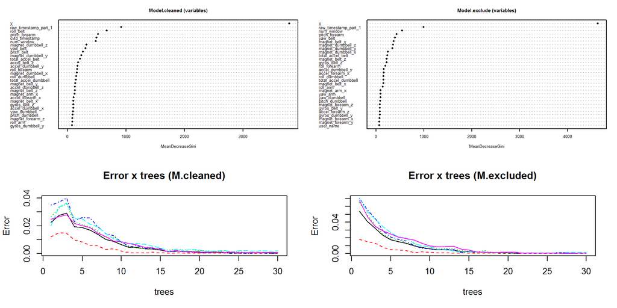

```r
par(mfrow=c(2,2))
varImpPlot(Model.cleaned, cex=0.4, pch=16, main='Model.cleaned (variables)')
varImpPlot(Model.exclude, cex=0.4, pch=16, main='Model.exclude (variables)')
plot(Model.cleaned, cex=0.2, main='Error x trees (M.cleaned)')
plot(Model.exclude, cex=0.2, main='Error x trees (M.excluded)')
```

## Conclusions

```r
predictions <- t(cbind(
    Exclude=as.data.frame(predict(Model.exclude, testing.final[, -To_exclude]), optional=TRUE),
    Cleaned=as.data.frame(predict(Model.cleaned, testing.final), optional=TRUE)
))
predictions
```

```
##         1   2   3   4   5   6   7   8   9   10  11  12  13  14  15  16  17  18  19  20
## Exclude "A" "A" "A" "A" "A" "A" "A" "A" "A" "A" "A" "A" "A" "A" "A" "A" "A" "A" "A" "A"
## Cleaned "A" "A" "B" "A" "A" "A" "A" "A" "A" "A" "A" "A" "B" "A" "A" "A" "A" "A" "A" "A"
```